# lab2 Classwork

Somnath Mukherjee

January 29, 2019

You might notice that a single observation that is substantially different from all other observations can make a large difference in the results of your regression analysis. If a single observation (or small group of observations) substantially changes your results, you would want to know about this and investigate further. In this lab exercise, we will conduct appropriate regression diagnostics to detect outliers (or unsual observations) as well as evaluate some model assumptions.

In this lab exercise, you will get familiar with and understand as listed:  
1. Conduct appropriate regression diagnostics to detect outliers (or unusual observations)  
2. Evaluate the assumptions of SLR using Residual Plots and the Normality Test.

### Lab set-up

```r
#load required packages
#install.packages('olsrr')
#install.packages('here')
#install.packages('car')
library(car)
library(olsrr) #package that runs residual plots and check assumptions for normality
library(here)
library(ggplot2)
```

```r
#read input file
theData = read.table(here('lab2','data','data2.txt'), header = F, stringsAsFactors = T) #use here() function to specify path
colnames(theData)=c("CITY","STATE","LAT","RANGE")
```

The latitude (LAT) and the mean monthly range (RANGE), which is the difference between mean monthly maximum and minimum temperatures, are given for a selected set of US cities. The following program performs a SLR using RANGE as the dependent variable and LAT as the independent variable.

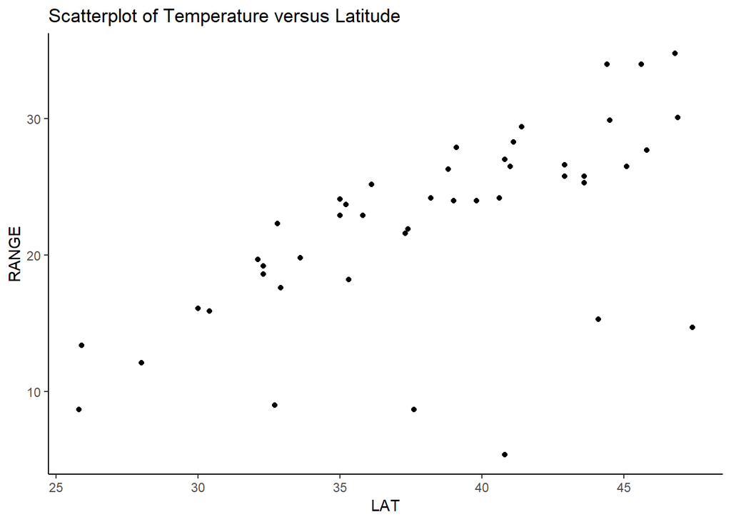

```r
ggplot(data = theData,aes(x = LAT,y = RANGE))+
  geom_point()+
  ggtitle('Scatterplot of Temperature versus Latitude') +
  theme_classic()
```

### Fitting the SLR model

Based on the scatterplot produced above, we assume that an appriopriate regression model relating RANGE and LAT is the linear model given by  
Y = b0 + b1X + e  
where Y is the RANGE, X is the LAT, and e is a random error term that is normally distributed with the mean 0 and the unknown variance.  
b0 is the estimate of the Y-intercept and b1 is the estimate of the slope coeffient.

```r
#fit the model
SLR_model <‐ lm(RANGE ~ LAT, data = theData)
summary(SLR_model)
```

```
##
## Call:
## lm(formula = RANGE ~ LAT, data = theData)
##
## Residuals:
##      Min       1Q   Median       3Q      Max
## -18.7823  -0.4865   0.8395   3.0765   7.1123
##
## Coefficients:
##             Estimate Std. Error t value Pr(>|t|)
## (Intercept)  -6.4793     5.5481  -1.168    0.249
## LAT           0.7515     0.1438   5.228 4.79e-06 ***
## ---
## Signif. codes:  0 '***' 0.001 '**' 0.01 '*' 0.05 '.' 0.1 ' ' 1
##
## Residual standard error: 5.498 on 43 degrees of freedom
## Multiple R-squared:  0.3886, Adjusted R-squared:  0.3744
## F-statistic: 27.33 on 1 and 43 DF,  p-value: 4.786e-06
```

### Observation Diagonistics[Regression outlier, Leverage obs.,influential obs.]

**Regression outlier:** We use rstudent(Deleted Studentized residual) measure to check for regression outlier.  
For our dataset if the value is >2 or <-2 then the point is an outlier.

```r
## R Student - used to check the regression outlier.
rStudent <‐ rstudent(SLR_model)
rStudent
```

```
##            1            2            3            4            5
##  0.148286052  0.379319552  0.049613620 -4.031139153 -1.729590948
##            6            7            8            9           10
## -2.556069688  0.103593254  0.212951968 -0.816294770 -0.086686352
##           11           12           13           14           15
## -0.466110618  0.188459452 -0.181304147  0.877738815  0.395884400
##           16           17           18           19           20
##  0.917491175  0.358998469  0.006332848  0.249345112 -0.089388274
##           21           22           23           24           25
## -0.169051071  1.170142163  0.258874868  0.661775088 -0.044523615
##           26           27           28           29           30
##  0.714052162  0.835266256  0.785941445  0.007242276  0.030606134
##           31           32           33           34           35
## -0.337584933  1.158756432 -2.209827196 -0.118507445  1.338616109
##           36           37           38           39           40
##  0.451992486  0.563406089  0.683296870  0.079810409  0.763749401
##           41           42           43           44           45
##  0.515130119  0.008725753 -2.980066675  0.543518183  0.153879521
```

```r
outlierTest(SLR_model) # run test to get possible outliers considering p-value using adjusted alpha level.(part of car package)
```

```
##    rstudent unadjusted p-value Bonferonni p
## 4 -4.031139         0.00022872     0.010292
```

**Leverage observation:** Unusally large X value than mean X.

```r
## Hat diagonal values - to identify leverage outlier(unusual X value)
HatDiag <‐ lm.influence(SLR_model)$hat # get Hat Diag values
cutoff <‐ 2*(length(coef(SLR_model))/length(HatDiag)) # cu‐off at 2*p/n
a <‐ theData[which(lm.influence(SLR_model)$hat > cutoff),] # Print obs with HAT > 2*p/n
cbind(a, HatDiag[HatDiag > cutoff]) #obs with high hatdiag value
```

```
##        CITY STATE  LAT RANGE HatDiag[HatDiag > cutoff]
## 9     Miami    FL 25.8   8.7                0.12686850
## 11    Tampa    FL 28.0  12.1                0.09295866
## 39 Brownsvl    TX 25.9  13.4                0.12518355
```

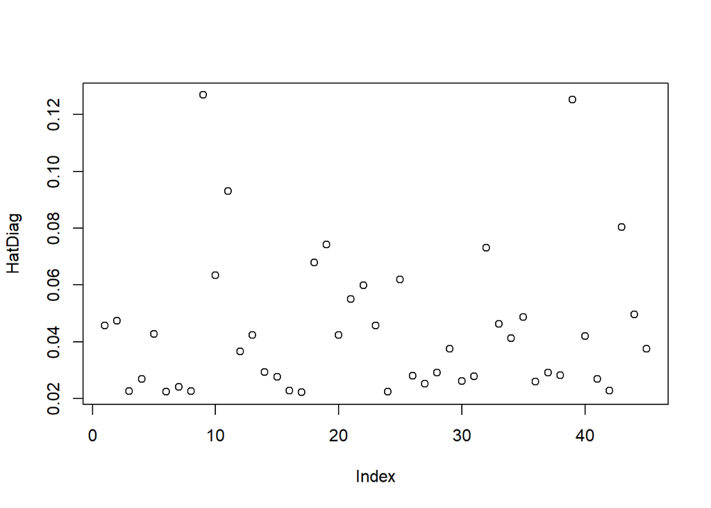

```r
plot(HatDiag, ylab="HatDiag")
```

**Influential observation** (based on DFFITS,DFBETAS,COOKSD):  
Astericks beside obs. denotes influential obs.

```r
# Get ALL INFLUENCE MEASURES DISCUSSED (DFFITS,DFBETAS,COOKSD)
influence.measures(SLR_model)
```

```
## Influence measures of
##   lm(formula = RANGE ~ LAT, data = theData) :
##
##       dfb.1_   dfb.LAT    dffit cov.r   cook.d    hat inf
## 1   0.026392 -0.023305  0.03248 1.097 5.40e-04 0.0458
## 2   0.069580 -0.061699  0.08464 1.093 3.65e-03 0.0474
## 3   0.002106 -0.001012  0.00755 1.072 2.92e-05 0.0226
## 4   0.187855 -0.280922 -0.67084 0.560 1.66e-01 0.0269   *
## 5  -0.289049  0.252898 -0.36524 0.954 6.37e-02 0.0427
## 6  -0.095110  0.038608 -0.38731 0.803 6.65e-02 0.0224   *
## 7  -0.002108  0.004466  0.01626 1.073 1.35e-04 0.0240
## 8   0.000126  0.004669  0.03245 1.070 5.38e-04 0.0227
## 9  -0.298734  0.282598 -0.31116 1.163 4.88e-02 0.1269   *
## 10 -0.019976  0.018203 -0.02258 1.119 2.61e-04 0.0635
## 11 -0.139515  0.130166 -0.14922 1.144 1.13e-02 0.0930   *
```

[output cut: 34 more lines]

```r
## To get individual outliers(influential obs.) run the codes below.
## based on DFFITS
DFFITS_model <‐ abs(dffits(SLR_model)) # get absolute values of DFFITS
b <‐ theData[which(DFFITS_model > 1),] # get DFFITS > 1
cbind(b, DFFITS = DFFITS_model[DFFITS_model > 1]) # Print obs with DFFITS >1
```

```
## [1] CITY   STATE  LAT    RANGE  DFFITS
## <0 rows> (or 0-length row.names)
```

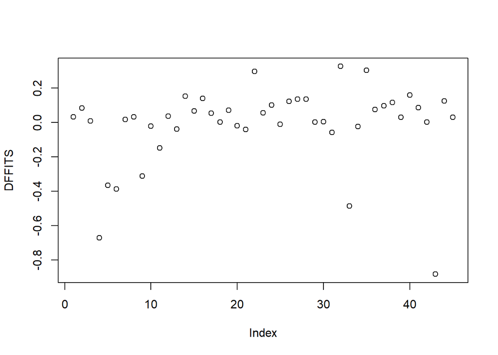

```r
plot(dffits(SLR_model), ylab="DFFITS") # Plot all DFFITS
```

```r
## DFBETAS (we are only checking for b1[LAT] for our case but b0[intercept] is also valid check)
DFBETAS_model <‐ abs(dfbetas(SLR_model)[, 'LAT']) # get absolute values of DFBETAS for LAT
c <‐ theData[which(DFBETAS_model > 1),] # get LAT DFBETAS > 1
cbind(c, DFBETA_LAT = DFBETAS_model[DFBETAS_model > 1]) # Print obs with LAT DFBETAS > 1
```

```
## [1] CITY       STATE      LAT        RANGE      DFBETA_LAT
## <0 rows> (or 0-length row.names)
```

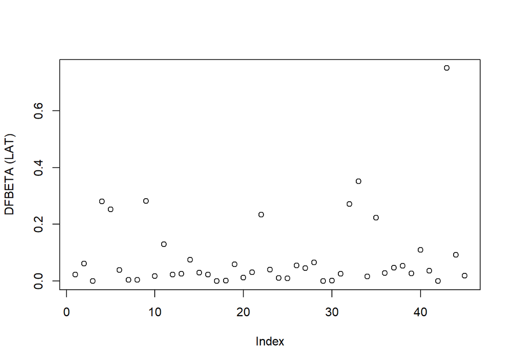

```r
plot(DFBETAS_model, ylab="DFBETA (LAT)") # Plot LAT DFBETAS
```

```r
## COOK's Distance
COOKS_mod <‐ cooks.distance(SLR_model) # get cook's D for all observations
cutoff <‐ 4/length(COOKS_mod) # cut off at 4/n
d <‐ theData[which(COOKS_mod > cutoff),]
cbind(d, COOKsD = COOKS_mod[COOKS_mod > cutoff])
```

```
##       CITY STATE  LAT RANGE    COOKsD
## 4   Eureka    CA 40.8   5.4 0.1661055
## 33  Eugene    OR 44.1  15.3 0.1086150
## 43 Seattle    WA 47.4  14.7 0.3283570
```

2. Evaluate the assumptions of SLR using Residual Plots and the Normality Test.

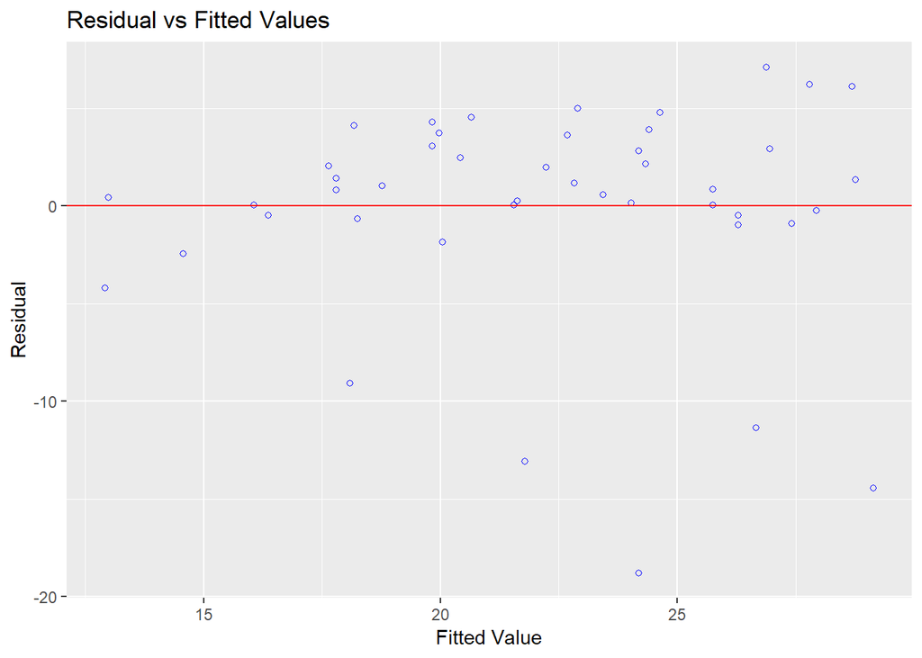

```r
ols_plot_resid_fit(SLR_model)
```

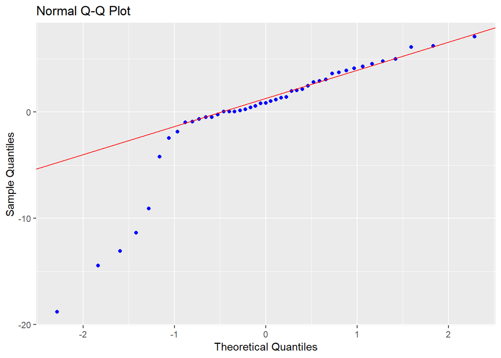

```r
ols_plot_resid_qq(SLR_model)
```

```r
ols_test_normality(SLR_model) ## Test normality
```

```
## -----------------------------------------------
##        Test             Statistic       pvalue
## -----------------------------------------------
## Shapiro-Wilk              0.7976         0.0000
## Kolmogorov-Smirnov        0.2502         0.0057
## Cramer-von Mises          2.7863         0.0000
## Anderson-Darling          3.1553         0.0000
## -----------------------------------------------
```